# Bootstrapped estimation of D scores for individual participants

Ian Hussey

05 April 2021

# Overview

IRAP trial-type *D* scores are calculated from an average of only 18 pairs of reaction times. This would be deemed as far too low anywhere else in the literature on reaction time based tasks. The implications of this can be seen in how poorly estimated any one IRAP D score is. We can observe this by bootstrapping reaction times for each participant’s *D* scores and noting how wide their confidence intervals are.

```r
# dependencies
library(tidyverse)
library(boot)
library(parallel)
library(bayestestR)
library(patchwork)
library(mdthemes)
library(lme4)
library(sjPlot)
library(emmeans)
library(ggstance)


# function to round all numeric vars in a data frame
round_df <- function(df, n_digits = 3) {
  df %>% mutate_if(is.numeric, round, digits = n_digits)
}

# for plot
dodge_width <- 0.25
```

# CI widths

Widths cant be directly compared between *D* and PI as they have different ranges, so *D* scores only.

Not meta analyzed as extreme skew in data means that residuals are very non-normal, violating assumptions and underestimating MAP estimates. Instead I simply present MAP estimates for each trial type & method, and then domain, trial type, and method.

## Plot by domain

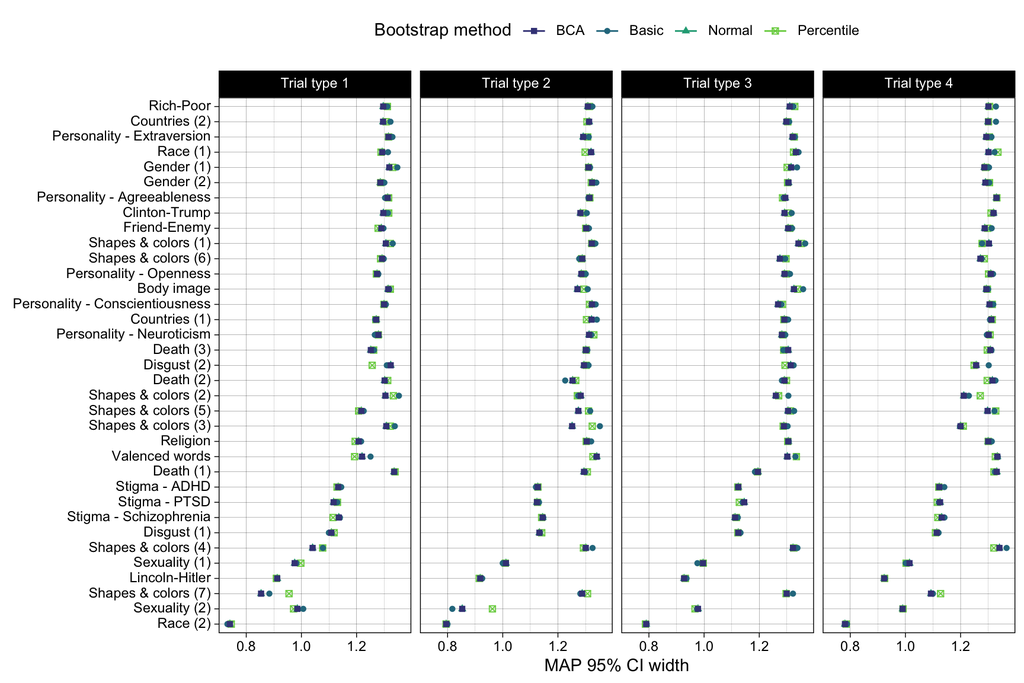

```r
# save to disk
data_ci_width_map_D <- read_rds("models/data_ci_width_map_D.rds")

# plot
p_ci_widths <-
  ggplot(data_ci_width_map_D, aes(MAP, domain, color = method, shape = method)) +
  geom_line() +
  geom_point() +
  scale_shape_manual(labels = c("BCA", "Basic", "Normal", "Percentile"), values = c(15, 16, 17, 7)) +
  scale_color_viridis_d(begin = 0.2, end = 0.8, labels = c("BCA", "Basic", "Normal", "Percentile")) +
  mdthemes::md_theme_linedraw() +
  facet_wrap(~ trial_type, ncol = 4, nrow = 1) +
  labs(x = "MAP 95% CI width",
       y = "",
       color = "Bootstrap method",
       shape = "Bootstrap method") +
  theme(legend.position = "top")

p_ci_widths
```

# Proportion different from zero

## Plots

### Compare scoring methods

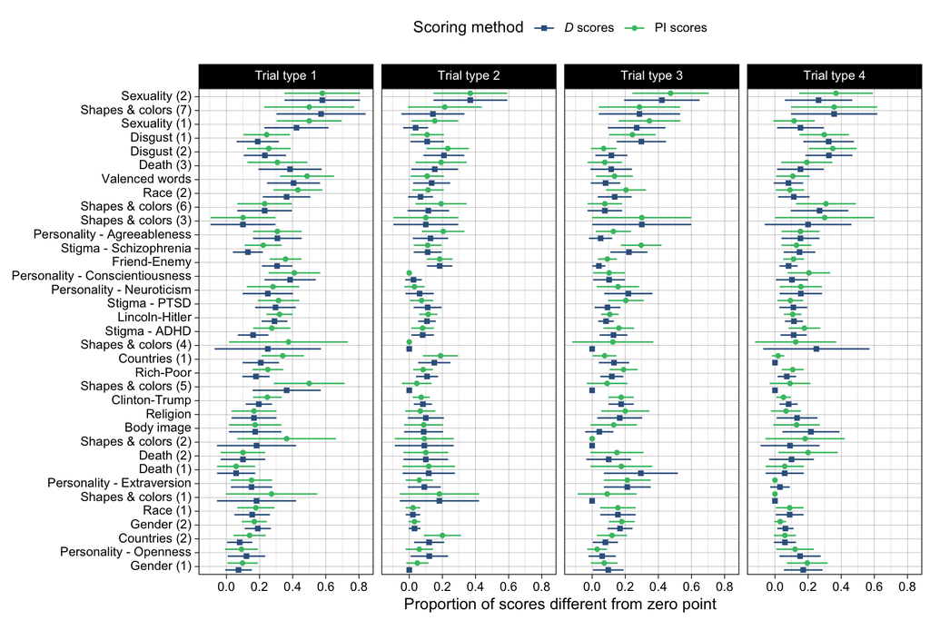

```r
data_diff_zero <- read_rds("models/data_diff_zero.rds")

p_diff_zero_scoring <-
  data_diff_zero %>%
  filter(method == "bca") %>%
  mutate(domain = fct_reorder(domain, proportion_diff_zero, .fun = mean)) %>%
  ggplot(aes(proportion_diff_zero, domain, color = DV_type, shape = DV_type)) +
  geom_linerangeh(aes(xmin = proportion_diff_zero - sqrt(variance)*1.96,
                      xmax = proportion_diff_zero + sqrt(variance)*1.96),
                  position = position_dodge(width = 1)) +
  geom_point(position = position_dodge(width = 1)) +
  scale_shape_manual(labels = c("*D* scores", "PI scores"), values = c(15, 16)) +
  scale_color_viridis_d(begin = 0.3, end = 0.7, labels = c("*D* scores", "PI scores")) +
  mdthemes::md_theme_linedraw() +
  facet_wrap(~ trial_type, ncol = 4) +
  labs(x = "Proportion of scores different from zero point",
       y = "",
       color = "Scoring method",
       shape = "Scoring method") +
  theme(legend.position = "top")

p_diff_zero_scoring
```

### Compare CI bootstrapping methods

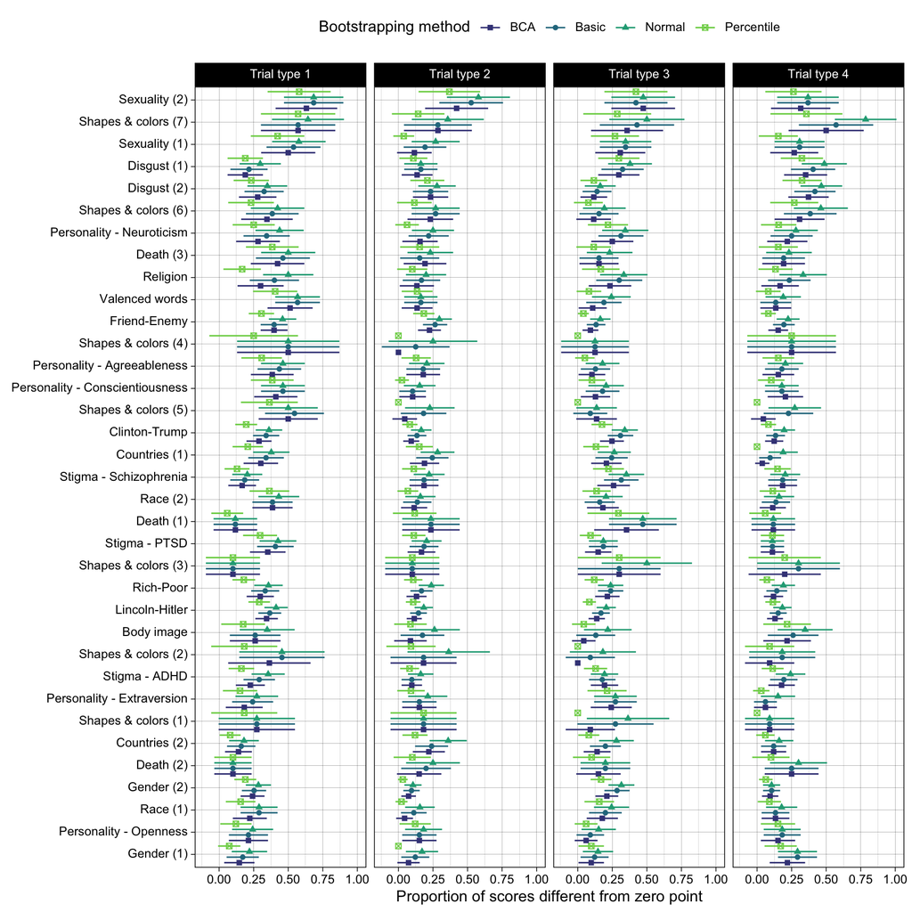

```r
p_diff_zero_method <-
  data_diff_zero %>%
  filter(DV_type == "*D* scores") %>%
  mutate(domain = fct_reorder(domain, proportion_diff_zero, .fun = mean)) %>%
  ggplot(aes(proportion_diff_zero, domain, color = method, shape = method)) +
  geom_linerangeh(aes(xmin = proportion_diff_zero - sqrt(variance)*1.96,
                      xmax = proportion_diff_zero + sqrt(variance)*1.96),
                  position = position_dodge(width = 1)) +
  geom_point(position = position_dodge(width = 1)) +
    scale_shape_manual(labels = c("BCA", "Basic", "Normal", "Percentile"), values = c(15, 16, 17, 7)) +
  scale_color_viridis_d(begin = 0.2, end = 0.8, labels = c("BCA", "Basic", "Normal", "Percentile")) +
  mdthemes::md_theme_linedraw() +
  facet_wrap(~ trial_type, ncol = 4) +
  labs(x = "Proportion of scores different from zero point",
       y = "",
       color = "Bootstrapping method",
       shape = "Bootstrapping method") +
  theme(legend.position = "top")

p_diff_zero_method
```

## Model

### Compare scoring methods

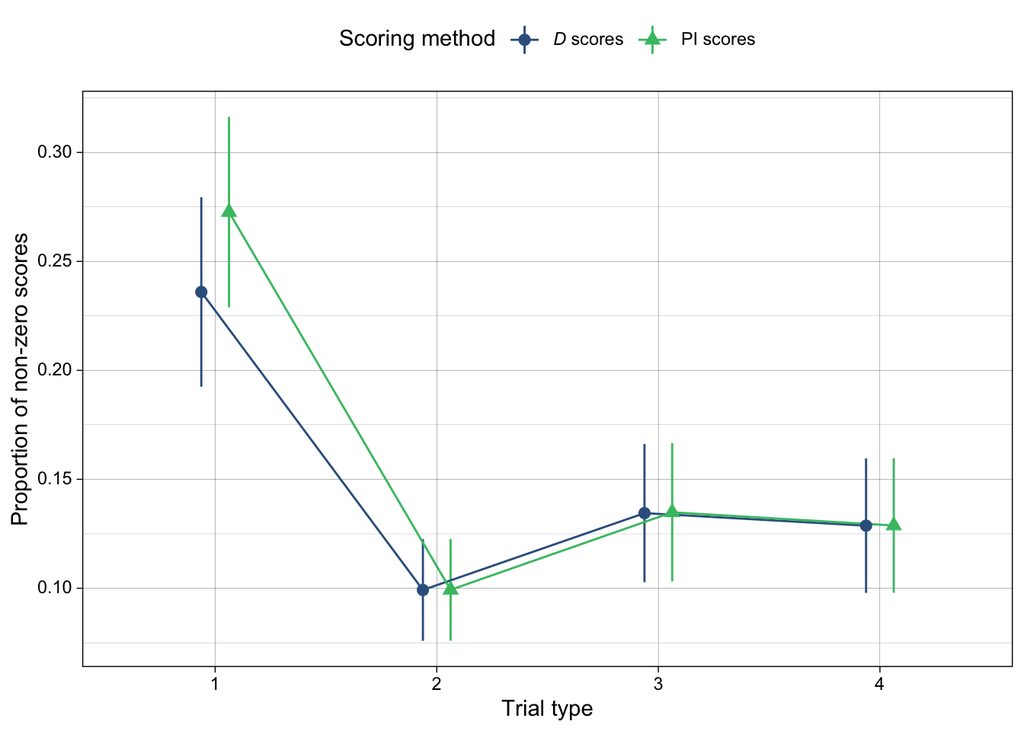

```r
# save to disk
results_emm_diff_zero_scoring <- read_rds("models/results_emm_diff_zero_scoring.rds")

p_prop_nonzero_scoring <- ggplot(results_emm_diff_zero_scoring, aes(trial_type, estimate, color = DV_type, shape = DV_type, group = DV_type)) +
  geom_linerange(aes(ymin = ci_lower, ymax = ci_upper), position = position_dodge(width = dodge_width)) +
  geom_line(position = position_dodge(width = dodge_width)) +
  geom_point(position = position_dodge(width = dodge_width), size = 2.5) +
  mdthemes::md_theme_linedraw() +
  scale_x_discrete(labels = c("Trial type 1" = "1", "Trial type 2" = "2", "Trial type 3" = "3", "Trial type 4" = "4")) +
  scale_color_viridis_d(begin = 0.3, end = 0.7, labels = c("*D* scores", "PI scores")) +
  labs(shape = "Scoring method",
       color = "Scoring method",
       x = "Trial type",
       y = "Proportion of non-zero scores") +
  theme(legend.position = "top")

p_prop_nonzero_scoring
```

### Compare CI bootstrapping methods

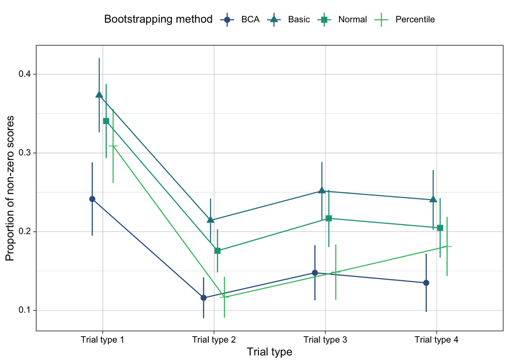

```r
# save to disk
results_emm_diff_zero_method <- read_rds("models/results_emm_diff_zero_method.rds")

p_prop_nonzero_method <- ggplot(results_emm_diff_zero_method, aes(trial_type, estimate, color = method, shape = method, group = method)) +
  geom_linerange(aes(ymin = ci_lower, ymax = ci_upper), position = position_dodge(width = dodge_width)) +
  geom_line(position = position_dodge(width = dodge_width)) +
  geom_point(position = position_dodge(width = dodge_width), size = 2.5) +
  mdthemes::md_theme_linedraw() +
  scale_x_discrete(labels = c("tt1" = "1", "tt2" = "2", "tt3" = "3", "tt4" = "4")) +
  scale_shape_discrete(labels = c("BCA", "Basic", "Normal", "Percentile")) +
  scale_color_viridis_d(begin = 0.3, end = 0.7, labels = c("BCA", "Basic", "Normal", "Percentile")) +
  labs(shape = "Bootstrapping method",
       color = "Bootstrapping method",
       x = "Trial type",
       y = "Proportion of non-zero scores") +
  theme(legend.position = "top")

p_prop_nonzero_method
```

# Proportion different from one another

Within domain and trial type

## Calculate discriminability

Many have argued that the zero point is arbitrary and not a useful reference point. Instead of asking “what proportion of *D*/PI scores are different from zero?”, we could also ask “what proportion of *D*/PI scores are different from one another?”

## Model

### Compare scoring methods

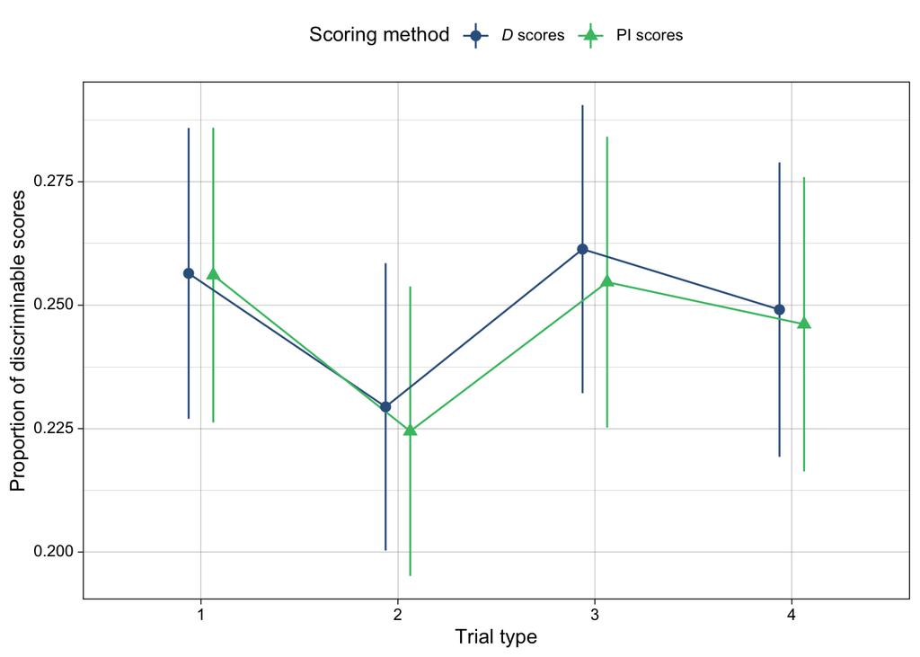

```r
# save to disk
results_emm_disciminability_scoring <- read_rds("models/results_emm_disciminability_scoring.rds")

p_prop_discriminable_scoring <- ggplot(results_emm_disciminability_scoring, aes(trial_type, estimate, color = DV_type, shape = DV_type, group = DV_type)) +
  geom_linerange(aes(ymin = ci_lower, ymax = ci_upper), position = position_dodge(width = dodge_width)) +
  geom_line(position = position_dodge(width = dodge_width)) +
  geom_point(position = position_dodge(width = dodge_width), size = 2.5) +
  scale_shape_discrete() +
  scale_color_viridis_d(begin = 0.3, end = 0.7) +
  mdthemes::md_theme_linedraw() +
  scale_x_discrete(labels = c("tt1" = "1", "tt2" = "2", "tt3" = "3", "tt4" = "4")) +
  labs(x = "Trial type",
       y = "Proportion of discriminable scores",
       color = "Scoring method",
       shape = "Scoring method") +
  theme(legend.position = "top")

p_prop_discriminable_scoring
```

### Compare CI bootstrapping methods

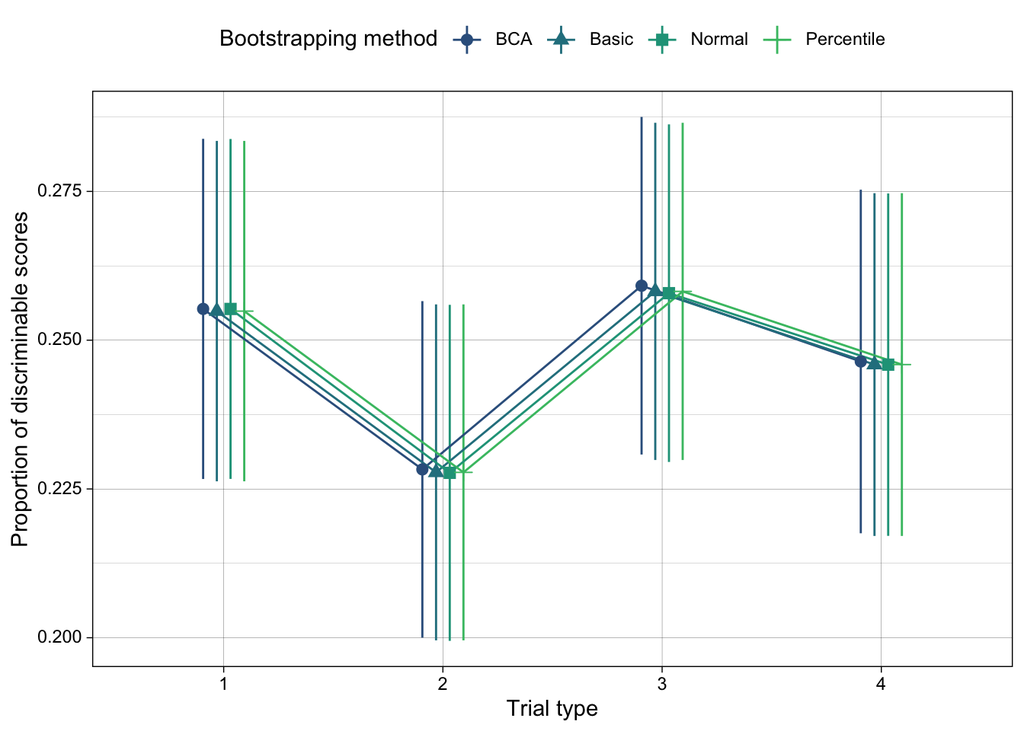

```r
# save to disk
results_emm_disciminability_method <- read_rds("models/results_emm_disciminability_method.rds")

p_prop_discriminable_method <-
  ggplot(results_emm_disciminability_method, aes(trial_type, estimate, color = method, shape = method, group = method)) +
  geom_linerange(aes(ymin = ci_lower, ymax = ci_upper), position = position_dodge(width = dodge_width)) +
  geom_line(position = position_dodge(width = dodge_width)) +
  geom_point(position = position_dodge(width = dodge_width), size = 2.5) +
  scale_shape_discrete(labels = c("BCA", "Basic", "Normal", "Percentile")) +
  scale_color_viridis_d(begin = 0.3, end = 0.7, labels = c("BCA", "Basic", "Normal", "Percentile")) +
  mdthemes::md_theme_linedraw() +
  scale_x_discrete(labels = c("tt1" = "1", "tt2" = "2", "tt3" = "3", "tt4" = "4")) +
  labs(x = "Trial type",
       y = "Proportion of discriminable scores",
       color = "Bootstrapping method",
       shape = "Bootstrapping method") +
  theme(legend.position = "top")

p_prop_discriminable_method
```

# CI widths as a proportion of observed range

## Model

### Compare scoring method

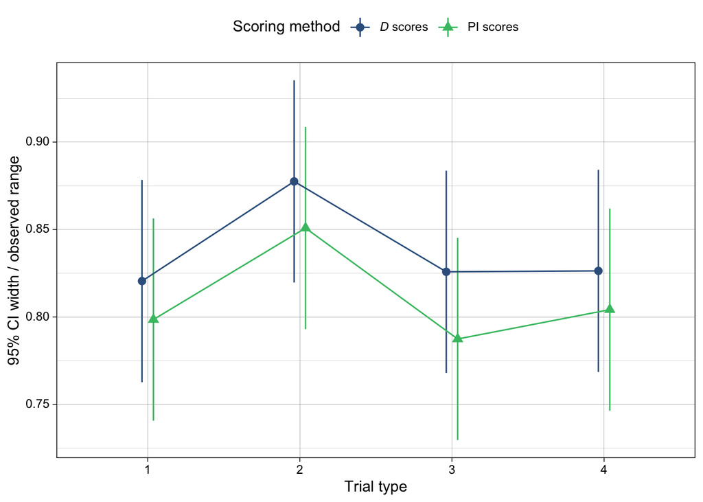

```r
# save to disk
results_emm_ci_width_proportions_scoring <- read_rds("models/results_emm_ci_width_proportions_scoring.rds")

# plot
dodge_width <- 0.15

p_ci_width_proportion_observed_range_scoring <-
  ggplot(results_emm_ci_width_proportions_scoring, aes(trial_type, estimate, color = DV_type, shape = DV_type, group = DV_type)) +
  geom_linerange(aes(ymin = ci_lower, ymax = ci_upper), position = position_dodge(width = dodge_width)) +
  geom_line(position = position_dodge(width = dodge_width)) +
  geom_point(position = position_dodge(width = dodge_width), size = 2.5) +
  scale_shape_discrete(labels = c("*D* scores", "PI scores")) +
  scale_color_viridis_d(begin = 0.3, end = 0.7, labels = c("*D* scores", "PI scores")) +
  mdthemes::md_theme_linedraw() +
  scale_x_discrete(labels = c("tt1" = "1", "tt2" = "2", "tt3" = "3", "tt4" = "4")) +
  labs(x = "Trial type",
       y = "95% CI width / observed range",
       color = "Scoring method",
       shape = "Scoring method") +
  theme(legend.position = "top")

p_ci_width_proportion_observed_range_scoring
```

### Compare CI bootstrapping methods

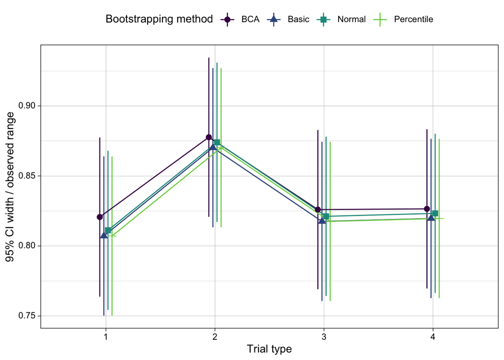

```r
# save to disk
results_emm_ci_width_proportions_method <- read_rds("models/results_emm_ci_width_proportions_method.rds")

# plot
p_ci_width_proportion_observed_range_method <-
  ggplot(results_emm_ci_width_proportions_method, aes(trial_type, estimate, color = method, shape = method, group = method)) +
  geom_linerange(aes(ymin = ci_lower, ymax = ci_upper), position = position_dodge(width = dodge_width)) +
  geom_line(position = position_dodge(width = dodge_width)) +
  geom_point(position = position_dodge(width = dodge_width), size = 2.5) +
  scale_shape_discrete(labels = c("BCA", "Basic", "Normal", "Percentile")) +
  scale_color_viridis_d(end = 0.8, labels = c("BCA", "Basic", "Normal", "Percentile")) +
  mdthemes::md_theme_linedraw() +
  scale_x_discrete(labels = c("tt1" = "1", "tt2" = "2", "tt3" = "3", "tt4" = "4")) +
  labs(x = "Trial type",
       y = "95% CI width / observed range",
       color = "Bootstrapping method",
       shape = "Bootstrapping method") +
  theme(legend.position = "top")

p_ci_width_proportion_observed_range_method
```